# DATA607 Project 4: Document Classification

Henry Otuadinma

April 15, 2019

# Project problem

It can be useful to be able to classify new “test” documents using already classified “training” documents. A common example is using a corpus of labeled spam and ham (non-spam) e-mails to predict whether or not a new document is spam.

For this project, you can start with a spam/ham dataset, then predict the class of new documents (either withheld from the training dataset or from another source such as your own spam folder). One example corpus: https://spamassassin.apache.org/publiccorpus/

The first video shows how to unzip the provided files.

Solutions:

Packages used

1. library(tidyverse)
2. library(tidytext)
3. library(tm)
4. library(caret)
5. library(e1071)
6. library(wordcloud)
7. library(R.utils)
8. library(DT)

## Download and Extract files

The spam and ham files are downloaded from spamassassin’s website:

```r
getFiles <- function(files,baseurl)
{
        for (i in 1: length(files))
          {
                fUrl <- str_c(baseurl,files[i])
                download.file(fUrl, destfile = files[i])
                Sys.sleep(1)
        }
}
```

```r
targetFiles <- c("20050311_spam_2.tar.bz2","20030228_easy_ham_2.tar.bz2")
```

```r
getFiles(targetFiles,"https://spamassassin.apache.org/old/publiccorpus/")
```

Extract the downloaded files twice. first, as a .bz2 and then as a .tar

```r
for (i in 1: length(targetFiles))
{
  bunzip2(targetFiles[i])
  untar(tarfile = str_replace(targetFiles[i], ".bz2", ""))
}
```

##### View all the sub-directories in the current working directory to be sure the files were extracted with their expected contents:

```r
list.dirs(path = ".", full.names = TRUE, recursive = TRUE)
```

```
##  [1] "."
##  [2] "./easy_ham_2"
##  [3] "./Henry-document-classification_files"
##  [4] "./Henry-document-classification_files/figure-html"
##  [5] "./rsconnect"
##  [6] "./rsconnect/documents"
##  [7] "./rsconnect/documents/Henry-document-classification.Rmd"
##  [8] "./rsconnect/documents/Henry-document-classification.Rmd/rpubs.com"
##  [9] "./rsconnect/documents/Henry-document-classification.Rmd/rpubs.com/rpubs"
## [10] "./spam_2"
```

```r
length(list.files("./easy_ham_2"))
```

```
## [1] 1400
```

```r
length(list.files("./spam_2"))
```

```
## [1] 1396
```

##### So, as it stands, all the files are now extracted in their separate folders, but I need to be sure that all the files in each of the folders are exactly named as every other on so that I won’t try to parse files that are neither a spam nor a ham

```r
hamFiles <- list.files("./easy_ham_2")
```

```r
spamFiles <- list.files("./spam_2")
```

```r
head(hamFiles)
```

```
## [1] "00001.1a31cc283af0060967a233d26548a6ce"
## [2] "00002.5a587ae61666c5aa097c8e866aedcc59"
## [3] "00003.19be8acd739ad589cd00d8425bac7115"
## [4] "00004.b2ed6c3c62bbdfab7683d60e214d1445"
## [5] "00005.07b9d4aa9e6c596440295a5170111392"
## [6] "00006.654c4ec7c059531accf388a807064363"
```

```r
head(spamFiles)
```

```
## [1] "00001.317e78fa8ee2f54cd4890fdc09ba8176"
## [2] "00002.9438920e9a55591b18e60d1ed37d992b"
## [3] "00003.590eff932f8704d8b0fcbe69d023b54d"
## [4] "00004.bdcc075fa4beb5157b5dd6cd41d8887b"
## [5] "00005.ed0aba4d386c5e62bc737cf3f0ed9589"
## [6] "00006.3ca1f399ccda5d897fecb8c57669a283"
```

```r
(notHamFile <- hamFiles[str_detect(hamFiles,"^\\d+\\.[:alnum:]") == FALSE])
```

```
## character(0)
```

```r
(notSpamFile <- spamFiles[str_detect(spamFiles,"^\\d+\\.[:alnum:]") == FALSE])
```

```
## character(0)
```

```r
if (file.exists("./easy_ham_2/cmds")) file.remove("./easy_ham_2/cmds")
if (file.exists("./spam_2/cmds")) file.remove("./spam_2/cmds")
```

##### I have to re-fetch the files in the folders again as the `cmds` files have been deleted, and then check the length of the content

```r
hamFiles <- list.files("./easy_ham_2")
```

```r
spamFiles <- list.files("./spam_2")
```

```r
length(spamFiles)
```

```
## [1] 1396
```

## Read all files into a dataframe

```r
hamSpamMails <- tibble()
hamSpamFolders <- c("./spam_2", "./easy_ham_2")
fileTypes <-c("spam", "ham")
allFileNames <- c(spamFiles, hamFiles)
```

```r
for (i in 1: length(hamSpamFolders))
  {
        type <- fileTypes[i]
        ff <- tibble(file = dir(hamSpamFolders[i],  full.names = TRUE)) %>% mutate(text = map(file, read_lines)) %>%
                transmute(id = basename(file), type = type, text) %>%
                unnest(text)
                hamSpamMails <- bind_rows(hamSpamMails, ff)
 }
```

```r
head(hamSpamMails)
```

```
## # A tibble: 6 x 3
##   id                        type  text
##   <chr>                     <chr> <chr>
## 1 00001.317e78fa8ee2f54cd4~ spam  From ilug-admin@linux.ie  Tue Aug  6 11:~
## 2 00001.317e78fa8ee2f54cd4~ spam  Return-Path: <ilug-admin@linux.ie>
## 3 00001.317e78fa8ee2f54cd4~ spam  Delivered-To: yyyy@localhost.netnoteinc.~
## 4 00001.317e78fa8ee2f54cd4~ spam  Received: from localhost (localhost [127~
## 5 00001.317e78fa8ee2f54cd4~ spam  "\tby phobos.labs.netnoteinc.com (Postfi~
## 6 00001.317e78fa8ee2f54cd4~ spam  "\tfor <jm@localhost>; Tue,  6 Aug 2002 ~
```

```r
allEmails <- hamSpamMails
```

```r
allEmails <- tibble::rowid_to_column(allEmails, "linenumber")
```

```r
datatable(head(allEmails), class = 'cell-border stripe', options = list(
  initComplete = JS(
    "function(settings, json) {",
    "$(this.api().table().header()).css({'background-color': '#26868d', 'color': '#fff', 'text-align': 'center !important'});",
    "$(this.api().table().body()).css({'color': '#000', 'text-align': 'center !important'});",
    "}")
))
```

|  | linenumber | id | type | text |
| --- | --- | --- | --- | --- |
| 1 | 1 | 00001.317e78fa8ee2f54cd4890fdc09ba8176 | spam | From ilug-admin@linux.ie Tue Aug 6 11:51:02 2002 |
| 2 | 2 | 00001.317e78fa8ee2f54cd4890fdc09ba8176 | spam | Return-Path: &lt;ilug-admin@linux.ie&gt; |
| 3 | 3 | 00001.317e78fa8ee2f54cd4890fdc09ba8176 | spam | Delivered-To: yyyy@localhost.netnoteinc.com |
| 4 | 4 | 00001.317e78fa8ee2f54cd4890fdc09ba8176 | spam | Received: from localhost (localhost [127.0.0.1]) |
| 5 | 5 | 00001.317e78fa8ee2f54cd4890fdc09ba8176 | spam | by phobos.labs.netnoteinc.com (Postfix) with ESMTP id 9E1F5441DD |
| 6 | 6 | 00001.317e78fa8ee2f54cd4890fdc09ba8176 | spam | for &lt;jm@localhost&gt;; Tue, 6 Aug 2002 06:48:09 -0400 (EDT) |

##### Group the dataframe by file type and check how many of each type is in the dataframe

```r
allEmails %>% group_by(type) %>% summarize(messages  = n_distinct(id)) %>% ungroup()
```

```
## # A tibble: 2 x 2
##   type  messages
##   <chr>    <int>
## 1 ham       1400
## 2 spam      1396
```

## Data cleaning

##### Next is to Create a corpus of the files but first striping all non-graphic characters so as to avoid the errors they can cause when `tm_map` is called. Then, I will remove characters like colons, hyphens, apostrophe, etc and replace them with spaces so that the words they separated will not be combined into one. Finally, I will remove punctuations, convert the corpus to lower case, remove all numbers, remove white spaces, and remove stop words.

```r
allEmails$text <- str_replace_all(allEmails$text,"[^[:graph:]]", " ")
```

```r
(allCorpus <- Corpus(VectorSource(allEmails$text)))
```

```
## <<SimpleCorpus>>
## Metadata:  corpus specific: 1, document level (indexed): 0
## Content:  documents: 328911
```

```r
stripJoiners <- content_transformer(function(x, pattern) {return (gsub(pattern, " ", x))})
```

```r
cleanMailCorpus <- tm_map(allCorpus, stripJoiners, "-")
cleanMailCorpus <- tm_map(cleanMailCorpus, stripJoiners, ":")
cleanMailCorpus <- tm_map(cleanMailCorpus, stripJoiners, "\\.")
cleanMailCorpus <- tm_map(cleanMailCorpus, stripJoiners, "'")
cleanMailCorpus <- tm_map(cleanMailCorpus, removePunctuation)
cleanMailCorpus <- tm_map(cleanMailCorpus, removeNumbers)
cleanMailCorpus <- tm_map(cleanMailCorpus, tolower)
cleanMailCorpus <- tm_map(cleanMailCorpus, stripWhitespace)
cleanMailCorpus <- tm_map(cleanMailCorpus, removeWords, stopwords("English"))
```

```r
mailsDf <- data.frame(text = get("content", cleanMailCorpus))
allEmails$text <- as.character(mailsDf$text)
```

```r
allMailsTokens <- allEmails %>%
   unnest_tokens(output = word, input = text) %>%
   # remove numbers
   filter(!str_detect(word, "^[0-9]*$")) %>%
   # remove stop words
   anti_join(stop_words) %>%
   # stem the words
   mutate(word = SnowballC::wordStem(word))
datatable(head(allMailsTokens), class = 'cell-border stripe', options = list(
  initComplete = JS(
    "function(settings, json) {",
    "$(this.api().table().header()).css({'background-color': '#26868d', 'color': '#fff', 'text-align': 'center !important'});",
    "$(this.api().table().body()).css({'color': '#000', 'text-align': 'center !important'});",
    "}")
))
```

|  | linenumber | id | type | word |
| --- | --- | --- | --- | --- |
| 1 | 1 | 00001.317e78fa8ee2f54cd4890fdc09ba8176 | spam | ilug |
| 2 | 1 | 00001.317e78fa8ee2f54cd4890fdc09ba8176 | spam | adminlinux |
| 3 | 1 | 00001.317e78fa8ee2f54cd4890fdc09ba8176 | spam | tue |
| 4 | 1 | 00001.317e78fa8ee2f54cd4890fdc09ba8176 | spam | aug |
| 5 | 2 | 00001.317e78fa8ee2f54cd4890fdc09ba8176 | spam | return |
| 6 | 2 | 00001.317e78fa8ee2f54cd4890fdc09ba8176 | spam | path |

## Weighting (tf-idf)

##### Term Frequency (tf) is simply to count how frequently a word occurs in a document. An alternative approach is term frequency inverse document frequency (tf-idf), which is the frequency of a term adjusted for how rarely it is used.

```r
cleanMailsTokensTfIdf <- allMailsTokens %>%
   count(type, word) %>%
   bind_tf_idf(term = word, document = type, n = n)
```

```r
datatable(head(cleanMailsTokensTfIdf), class = 'cell-border stripe', options = list(
  initComplete = JS(
    "function(settings, json) {",
    "$(this.api().table().header()).css({'background-color': '#26868d', 'color': '#fff', 'text-align': 'center !important'});",
    "$(this.api().table().body()).css({'color': '#000', 'text-align': 'center !important'});",
    "}")
))
```

|  | type | word | n | tf | idf | tf_idf |
| --- | --- | --- | --- | --- | --- | --- |
| 1 | ham | a | 6 | 1.29764520649861e-05 | 0 | 0 |
| 2 | ham | aa | 35 | 7.56959703790854e-05 | 0 | 0 |
| 3 | ham | aaa | 36 | 7.78587123899164e-05 | 0 | 0 |
| 4 | ham | aaaaaaaaaa | 5 | 1.08137100541551e-05 | 0.693147180559945 | 7.49549263543031e-06 |
| 5 | ham | aaaaaaaaaaaaaaaaaaaaa | 1 | 2.16274201083101e-06 | 0.693147180559945 | 1.49909852708606e-06 |
| 6 | ham | aaaaaaaacwdpgqggbgaaaaaawaaaaaaaaeyaaaaagouaaaaaaaalackaaaaaaasaiwaaaaaaawag | 1 | 2.16274201083101e-06 | 0.693147180559945 | 1.49909852708606e-06 |

## Exploratory analysis

##### Visualisations: There are some very low frequent terms in the clean data. in some cases, rarely occuring terms might have important descriptive values in the documents they occur.

```r
# Before weighting
hams <- allMailsTokens %>% group_by(type) %>% filter(type == "ham") %>% count(word, sort = TRUE) %>% ungroup()
spams <- allMailsTokens %>% group_by(type) %>% filter(type == "spam") %>% count(word, sort = TRUE) %>% ungroup()
```

```r
head(hams)
```

```
## # A tibble: 6 x 3
##   type  word       n
##   <chr> <chr>  <int>
## 1 ham   org    10661
## 2 ham   net    10536
## 3 ham   id     10348
## 4 ham   list   10014
## 5 ham   receiv  9629
## 6 ham   aug     7922
```

#### Bar plots

##### Before weighting

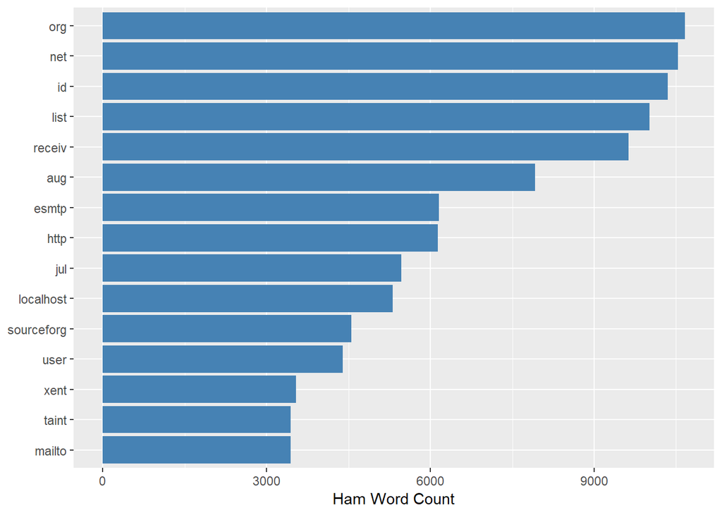

```r
# For hams

hams %>%
        top_n(15) %>%
        mutate(word = reorder(word, n)) %>%
        ggplot(aes(word, n))+
        geom_col(show.legend = FALSE, fill = "steelblue") +
        labs(y= "Ham Word Count", x=NULL)+
        coord_flip()
```

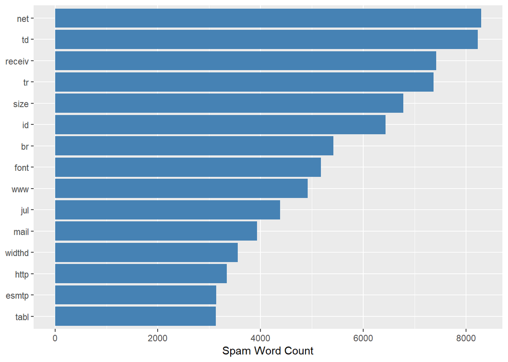

```r
# For spams
spams %>%
        top_n(15) %>%
        mutate(word = reorder(word, n)) %>%
        ggplot(aes(word, n))+
        geom_col(show.legend = FALSE, fill = "steelblue") +
        labs(y= "Spam Word Count", x=NULL)+
        coord_flip()
```

#### After weighting

##### sorting the tf-idf data frame and convert word to a factor column

```r
mailsPlot <- cleanMailsTokensTfIdf %>%
  arrange(desc(tf_idf)) %>%
  mutate(word = factor(word, levels = rev(unique(word))))
```

```r
datatable(head(mailsPlot), class = 'cell-border stripe', options = list(
  initComplete = JS(
    "function(settings, json) {",
    "$(this.api().table().header()).css({'background-color': '#26868d', 'color': '#fff', 'text-align': 'center !important'});",
    "$(this.api().table().body()).css({'color': '#000', 'text-align': 'center !important'});",
    "}")
))
```

|  | type | word | n | tf | idf | tf_idf |
| --- | --- | --- | --- | --- | --- | --- |
| 1 | ham | razor | 2776 | 0.00600377182206689 | 0.693147180559945 | 0.00416149751119091 |
| 2 | spam | helvetica | 2522 | 0.00432553696173049 | 0.693147180559945 | 0.00299823374943132 |
| 3 | ham | exmh | 1704 | 0.00368531238645604 | 0.693147180559945 | 0.00255446389015465 |
| 4 | ham | zzzlist | 1185 | 0.00256284928283475 | 0.693147180559945 | 0.00177643175459698 |
| 5 | spam | faceari | 1475 | 0.0025298045275783 | 0.693147180559945 | 0.00175352687565868 |
| 6 | ham | egwn | 1074 | 0.00232278491963251 | 0.693147180559945 | 0.00161003181809043 |

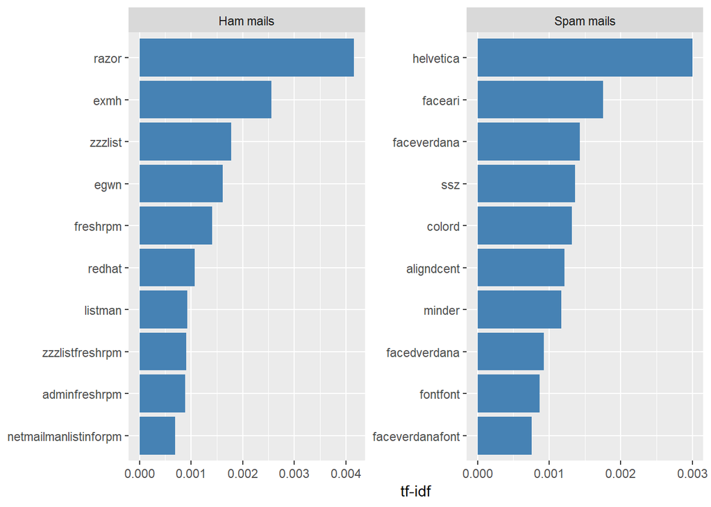

```r
# graph the top 10 tokens for both ham and spam
mailsPlot %>%
  filter(type %in% c('ham', 'spam')) %>%
  mutate(type = factor(type, levels = c('ham', 'spam'),
                        labels = c("Ham mails", "Spam mails"))) %>%
  group_by(type) %>%
  top_n(10) %>%
  ungroup() %>%
  ggplot(aes(word, tf_idf)) +
  geom_col(fill = "steelblue") +
  labs(x = NULL, y = "tf-idf") +
  facet_wrap(~type, scales = "free") +
  coord_flip()
```

##### Word cloud of top 50 ham and spam mails before and after tf-idf weighting. This is to see if the same words/terms that occured very frequently before weighting are still as such after weighting

```r
# After Weighting
hams50 <- top_n(subset(cleanMailsTokensTfIdf, type == 'ham'), 50)
spams50 <- top_n(subset(cleanMailsTokensTfIdf, type == 'spam'), 50)
```

#### For Hams

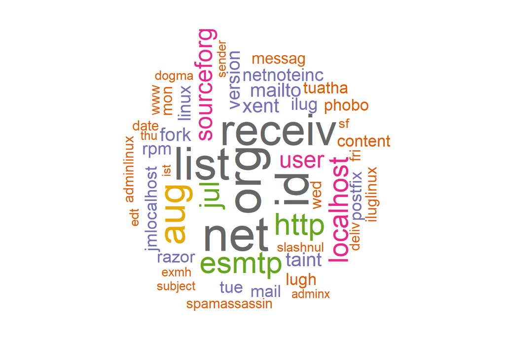

```r
# Before weighting

wordcloud(words = hams$word, freq = hams$n, min.freq = 1,
          max.words=50, random.order=FALSE, rot.per=0.35,
          colors=brewer.pal(8, "Dark2"))
```

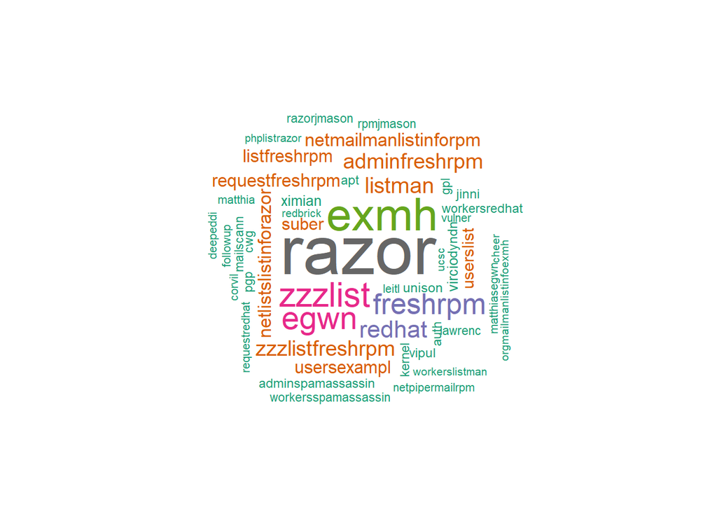

```r
#After weighting
wordcloud(words = hams50$word, freq = hams50$n, min.freq = 1,
          max.words=50, random.order=FALSE, rot.per=0.35,
          colors=brewer.pal(8, "Dark2"))
```

#### For Spams

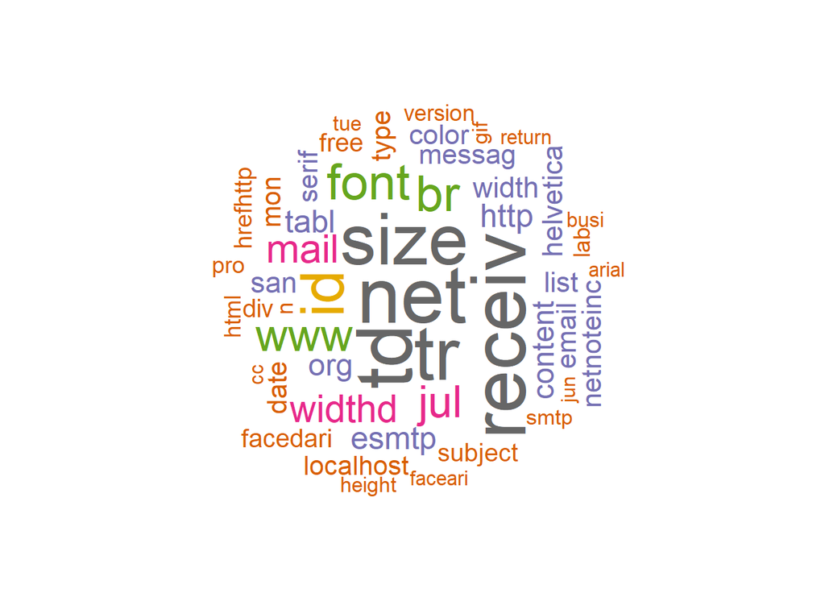

```r
# Bfore weighting
wordcloud(words = spams$word, freq = hams$n, min.freq = 1,
          max.words=50, random.order=FALSE, rot.per=0.35,
          colors=brewer.pal(8, "Dark2"))
```

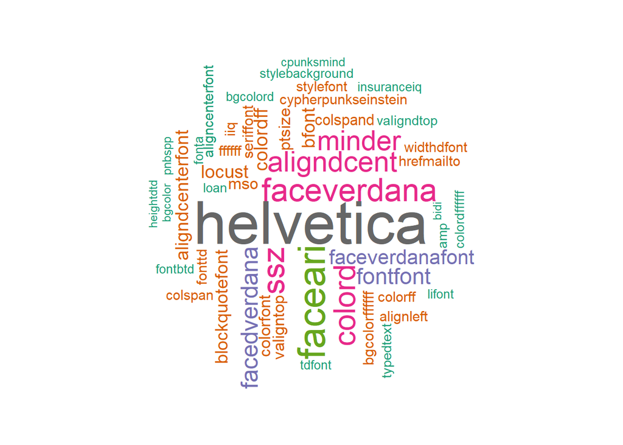

```r
# After Weighting
wordcloud(words = spams50$word, freq = spams50$n, min.freq = 1,
          max.words=50, random.order=FALSE, rot.per=0.35,
          colors=brewer.pal(8, "Dark2"))
```

##### Apparently the visualisations for normal word count and tf-idf are different with words that appear more in the former almost not showing up in the later

## Training, Classification and prediction

```r
set.seed(12)
randomisedSet <- allMailsTokens[sample(nrow(allMailsTokens)),]
```

```r
randomisedCorpus <- Corpus(VectorSource(randomisedSet$word))
```

```r
randommisedDTM <- DocumentTermMatrix(randomisedCorpus)
```

```r
trainingDim <- dim(randomisedSet)[1]%/%4*3
trainingSet <- randomisedSet[1:trainingDim,]
txtSet <- dim(randomisedSet)[1]
```

```r
trainingSet <- randomisedSet[1:trainingDim,]
testingSet <- randomisedSet[(trainingDim+1):txtSet,]
```

```r
trainingDTM <- randommisedDTM[1:trainingDim,]
testDTM <- randommisedDTM[(trainingDim+1):txtSet,]
```

```r
trainingLabels <- trainingSet$type
testLabels <- testingSet$type
```

## Sparsity

```r
threshold <- 0.5

minFreq = round(randommisedDTM$nrow*(threshold/100),0)
```

```r
frequentWords <- findFreqTerms(x = randommisedDTM, lowfreq = minFreq)
```

```r
length(testDTM)
```

```
## [1] 6
```

```r
length(frequentWords)
```

```
## [1] 15
```

```r
trainingDTMFreq <- trainingDTM[ , frequentWords]
testDTMFreq <- testDTM[ , frequentWords]

dim(trainingDTMFreq)
```

```
## [1] 784068     15
```

```r
categoriseValues <- function(x) {
  x <- ifelse(x > 0, "Yes", "No")
}
```

```r
trainingText <- apply(trainingDTMFreq,  MARGIN =  2, categoriseValues)
testText <- apply(testDTMFreq, MARGIN = 2, categoriseValues)
```

## Naive Bayes Classifier

##### This is based on Bayes rule, fequency analysis of occurances of words and an independence assumption (the naive part). The Naive Bayes classifier assigns a probability that a new sample is in one class or another (spam or ham). Then, from the words contained or not contained in the message, it will compute the probability that a message is either a spam or ham. The Naive Bayes can be considered for this processes because the mails can be categorised as ham or spam (the input are categorical)

```r
classifier <- naiveBayes(trainingText, factor(trainingLabels))
```

```r
testPrediction <- predict(classifier, testText)
```

## Prediction Statistics

```r
confusionMatrix(data = testPrediction, reference = factor(testLabels),
                positive = "spam", dnn = c("Prediction", "Actual"))
```

```
## Confusion Matrix and Statistics
##
##           Actual
## Prediction    ham   spam
##       ham   19657   9767
##       spam  95906 136027
##
##                Accuracy : 0.5957
##                  95% CI : (0.5938, 0.5976)
##     No Information Rate : 0.5578
##     P-Value [Acc > NIR] : < 2.2e-16
##
##                   Kappa : 0.1117
##
##  Mcnemar's Test P-Value : < 2.2e-16
##
##             Sensitivity : 0.9330
##             Specificity : 0.1701
##          Pos Pred Value : 0.5865
##          Neg Pred Value : 0.6681
##              Prevalence : 0.5578
##          Detection Rate : 0.5205
##    Detection Prevalence : 0.8874
##       Balanced Accuracy : 0.5516
##
##        'Positive' Class : spam
##
```

## References

1. [Supervised Classification with Text Data](https://cfss.uchicago.edu/notes/supervised-text-classification/)
2. [Text mining example: spam filtering](https://www3.nd.edu/~steve/computing_with_data/20_text_mining/text_mining_example.html#/)